# Bellabeat-CaseStudy

[figure not shown]

- 1. Introduction
- 2. Ask
  - 2.1 Business task
  - 2.2 Key stakeholders
- 3. Prepare
  - 3.1 Dataset
  - 3.2 Data Source
  - 3.3 Data Integrity and Credibility
  - 3.4 Data Selection
- 4. Process
  - 4.1 Loading Packages
  - 4.2 Importing Dataset
  - 4.2 Data Cleaning
  - 4.4 Sorting and Filtering
- 5. Analyze
- 6. Share
- 7. Act

# **1. Introduction**

Bellabeat is a high-tech company that manufactures health-focused smart products. In 2014, Urška Sršen and Sando Mur founded the company and developed one of the first wearables specifically designed for women. It uses beautifully designed technology to inform and inspire women around the world. Bellabeat Collects data on activity, sleep, stress, and reproductive health, allowing it to empower women with knowledge about their health and habits.

Bellabeat had, in 2016, opened offices around the world and launched multiple products that became available through a growing number of online retailers in addition to their e-commerce channel on their website. Some of Bellabeat’s products include:

- **Bellabeat app**: The Bellabeat app provides users with health data related to their activity, sleep, stress, menstrual cycle, and mindfulness habits.
- **Leaf**: Bellabeat’s classic wellness tracker can be worn as a bracelet, necklace, or clip. The Leaf Tracker connects to the Bellabeat app to track activity, sleep, and stress.
- **Time**: This wellness watch combines the timeless look of a classic timepiece with smart technology to track user activity, sleep, and stress.
- **Spring**: This is a water bottle that tracks daily water intake using smart technology to ensure that you are appropriately hydrated throughout the day. The Spring bottle connects to the Bellabeat app to track your hydration levels.

As a data analyst working on the marketing team at Bellabeat, I've been asked to gain insight into how consumers use their smartwatches. I'll be presenting my analysis to the executive team along with high-level recommendations for Beallabeat's marketing strategy.

# **2. Ask**

### 2.1 Business task

Analyze smart device usage data to gain insight into how consumers use non-Bellabeat smart devices. Then, select one Bellabeat product to apply these insights.

Using FitBit Fitness Tracker data available in the public domain through Mobius and hosted on Kaggle, I will analyze data from over 30 FitBit users over a two-month span. This analysis will provide insights into how these users interact with their smartwatches, which can inform Bellabeat's research and marketing strategies

**Questions**:

1. What are some trends in smart device usage?
2. How could these trends apply to Bellabeat customers?
3. How could these trends help influence Bellabeat marketing strategy?

### 2.2 Key Stakeholders

It’s important to understand the audience to effectively communicate my analysis and share recommendations.

- **Urška Sršen**: Bellabeat’s co-founder and Chief Creative Officer.
- **Sando Mur**: Bellabeat’s cofounder; key member of the Bellabeat executive team.
- **Bellabeat marketing analytics team**: A team of data analysts responsible for collecting, analyzing, and reporting data that helps guide Bellabeat’s marketing strategy.

# **3. Prepare**

### 3.1 Dataset

The FitBit Fitness Tracker Data is a 3rd party, public dataset that measures smart device users’ daily habits. This dataset contains personal fitness data from **35** fitbit users, including physical activity, heart rate, and sleep monitoring.

### 3.2 Data Source

The data is publically available and maintained through Mobius. It was collected through a survey via Amazon Mechanical Turk between 03.12.2016 and 05.12.2016. [Dataset Link](http://www.kaggle.com/datasets/arashnic/fitbit)

### 3.3 Data Integrity and Credibility

The dataset comprises responses from only 35 users, which may not accurately reflect the broader population in consideration. Additionally, the absence of information regarding users' locations is noteworthy, as preferences, activities, and habits can vary significantly based on geographical and cultural factors. The age of the users wasn't provided, yet age plays a crucial role in determining users' agility, strength, and overall activity levels.

### 3.4 Data Selection

- mturkfitbit_export_3.12.16-4.11.16/Fitabase Data 3.12.16-4.11.16/dailyActivity_merged.csv
- mturkfitbit_export_4.12.16-5.12.16/Fitabase Data 4.12.16-5.12.16/dailyActivity_merged.csv

The dailyActivity_merged file contains user IDs, dates, step counts, distances, activity level measures, and calories burned. This data was recorded over two months, providing ample information for analysis.

Other data files, such as sleepDay_merged, could be useful. However, this dataset was recorded for only one month and includes less relevant measurements. I believe focusing on activity data and calories burned will yield more valuable insights.

# **4. Process**

I have chosen **Python** for processing, analysis, and visualization in this project due to the substantial size of some datasets, which contain thousands of rows. Using Kaggle, which supports Jupyter Notebooks, allows me to share this project with a broad audience of like-minded individuals and receive feedback from enthusiasts.

Additionally, Python enables me to seamlessly complete the entire data analysis process—from data cleaning to visualization—within the same environment.

### 4.1 Loading Packages

```python
import numpy as np
import pandas as pd
import matplotlib.pyplot as plt
import seaborn as sb
import datetime as dt
```

### 4.2 Importing Dataset

```python
import os # Importing the os module to interact with the operating system
for dirname, _, filenames in os.walk('Kaggle'):  # Walking through the 'Kaggle' dataset directory
    for filename in filenames:
        print(os.path.join(dirname, filename))
```

```
Kaggle\mturkfitbit_export_3.12.16-4.11.16\Fitabase Data 3.12.16-4.11.16\dailyActivity_merged.csv
Kaggle\mturkfitbit_export_3.12.16-4.11.16\Fitabase Data 3.12.16-4.11.16\heartrate_seconds_merged.csv
Kaggle\mturkfitbit_export_3.12.16-4.11.16\Fitabase Data 3.12.16-4.11.16\hourlyCalories_merged.csv
Kaggle\mturkfitbit_export_3.12.16-4.11.16\Fitabase Data 3.12.16-4.11.16\hourlyIntensities_merged.csv
Kaggle\mturkfitbit_export_3.12.16-4.11.16\Fitabase Data 3.12.16-4.11.16\hourlySteps_merged.csv
Kaggle\mturkfitbit_export_3.12.16-4.11.16\Fitabase Data 3.12.16-4.11.16\minuteCaloriesNarrow_merged.csv
Kaggle\mturkfitbit_export_3.12.16-4.11.16\Fitabase Data 3.12.16-4.11.16\minuteIntensitiesNarrow_merged.csv
Kaggle\mturkfitbit_export_3.12.16-4.11.16\Fitabase Data 3.12.16-4.11.16\minuteMETsNarrow_merged.csv
Kaggle\mturkfitbit_export_3.12.16-4.11.16\Fitabase Data 3.12.16-4.11.16\minuteSleep_merged.csv
Kaggle\mturkfitbit_export_3.12.16-4.11.16\Fitabase Data 3.12.16-4.11.16\minuteStepsNarrow_merged.csv
Kaggle\mturkfitbit_export_3.12.16-4.11.16\Fitabase Data 3.12.16-4.11.16\weightLogInfo_merged.csv
Kaggle\mturkfitbit_export_4.12.16-5.12.16\Fitabase Data 4.12.16-5.12.16\dailyActivity_merged.csv
Kaggle\mturkfitbit_export_4.12.16-5.12.16\Fitabase Data 4.12.16-5.12.16\dailyCalories_merged.csv
Kaggle\mturkfitbit_export_4.12.16-5.12.16\Fitabase Data 4.12.16-5.12.16\dailyIntensities_merged.csv
Kaggle\mturkfitbit_export_4.12.16-5.12.16\Fitabase Data 4.12.16-5.12.16\dailySteps_merged.csv
Kaggle\mturkfitbit_export_4.12.16-5.12.16\Fitabase Data 4.12.16-5.12.16\heartrate_seconds_merged.csv
Kaggle\mturkfitbit_export_4.12.16-5.12.16\Fitabase Data 4.12.16-5.12.16\hourlyCalories_merged.csv
Kaggle\mturkfitbit_export_4.12.16-5.12.16\Fitabase Data 4.12.16-5.12.16\hourlyIntensities_merged.csv
Kaggle\mturkfitbit_export_4.12.16-5.12.16\Fitabase Data 4.12.16-5.12.16\hourlySteps_merged.csv
Kaggle\mturkfitbit_export_4.12.16-5.12.16\Fitabase Data 4.12.16-5.12.16\minuteCaloriesNarrow_merged.csv
Kaggle\mturkfitbit_export_4.12.16-5.12.16\Fitabase Data 4.12.16-5.12.16\minuteCaloriesWide_merged.csv
Kaggle\mturkfitbit_export_4.12.16-5.12.16\Fitabase Data 4.12.16-5.12.16\minuteIntensitiesNarrow_merged.csv
Kaggle\mturkfitbit_export_4.12.16-5.12.16\Fitabase Data 4.12.16-5.12.16\minuteIntensitiesWide_merged.csv
Kaggle\mturkfitbit_export_4.12.16-5.12.16\Fitabase Data 4.12.16-5.12.16\minuteMETsNarrow_merged.csv
Kaggle\mturkfitbit_export_4.12.16-5.12.16\Fitabase Data 4.12.16-5.12.16\minuteSleep_merged.csv
Kaggle\mturkfitbit_export_4.12.16-5.12.16\Fitabase Data 4.12.16-5.12.16\minuteStepsNarrow_merged.csv
Kaggle\mturkfitbit_export_4.12.16-5.12.16\Fitabase Data 4.12.16-5.12.16\minuteStepsWide_merged.csv
Kaggle\mturkfitbit_export_4.12.16-5.12.16\Fitabase Data 4.12.16-5.12.16\sleepDay_merged.csv
Kaggle\mturkfitbit_export_4.12.16-5.12.16\Fitabase Data 4.12.16-5.12.16\weightLogInfo_merged.csv
```

#### Merging Dataframes:

We will now load the imported data into a dataframe and merge our two CSV files into a single dataset.

While we will further verify data integrity as we progress, checking the shape of our dataframes confirms that the two datasets have been successfully combined.

```python
df1= pd.read_csv('Kaggle/mturkfitbit_export_3.12.16-4.11.16/Fitabase Data 3.12.16-4.11.16/dailyActivity_merged.csv')

df2 =pd.read_csv('Kaggle/mturkfitbit_export_4.12.16-5.12.16/Fitabase Data 4.12.16-5.12.16/dailyActivity_merged.csv')

df = pd.concat([df1,df2])
```

```python
df1.shape
```

```
(457, 15)
```

```python
df2.shape
```

```
(940, 15)
```

```python
df.shape
```

```
(1397, 15)
```

```python
df.columns
```

```
Index(['Id', 'ActivityDate', 'TotalSteps', 'TotalDistance', 'TrackerDistance',
       'LoggedActivitiesDistance', 'VeryActiveDistance',
       'ModeratelyActiveDistance', 'LightActiveDistance',
       'SedentaryActiveDistance', 'VeryActiveMinutes', 'FairlyActiveMinutes',
       'LightlyActiveMinutes', 'SedentaryMinutes', 'Calories'],
      dtype='object')
```

```python
df.head()
```

|  | Id | ActivityDate | TotalSteps | TotalDistance | TrackerDistance | LoggedActivitiesDistance | VeryActiveDistance | ModeratelyActiveDistance | LightActiveDistance | SedentaryActiveDistance | VeryActiveMinutes | FairlyActiveMinutes | LightlyActiveMinutes | SedentaryMinutes | Calories |
| --- | --- | --- | --- | --- | --- | --- | --- | --- | --- | --- | --- | --- | --- | --- | --- |
| 0 | 1503960366 | 3/25/2016 | 11004 | 7.11 | 7.11 | 0.0 | 2.57 | 0.46 | 4.07 | 0.0 | 33 | 12 | 205 | 804 | 1819 |
| 1 | 1503960366 | 3/26/2016 | 17609 | 11.55 | 11.55 | 0.0 | 6.92 | 0.73 | 3.91 | 0.0 | 89 | 17 | 274 | 588 | 2154 |
| 2 | 1503960366 | 3/27/2016 | 12736 | 8.53 | 8.53 | 0.0 | 4.66 | 0.16 | 3.71 | 0.0 | 56 | 5 | 268 | 605 | 1944 |
| 3 | 1503960366 | 3/28/2016 | 13231 | 8.93 | 8.93 | 0.0 | 3.19 | 0.79 | 4.95 | 0.0 | 39 | 20 | 224 | 1080 | 1932 |
| 4 | 1503960366 | 3/29/2016 | 12041 | 7.85 | 7.85 | 0.0 | 2.16 | 1.09 | 4.61 | 0.0 | 28 | 28 | 243 | 763 | 1886 |

```python
df.describe() # Descriptive statistics of the dataset.
```

|  | Id | TotalSteps | TotalDistance | TrackerDistance | LoggedActivitiesDistance | VeryActiveDistance | ModeratelyActiveDistance | LightActiveDistance | SedentaryActiveDistance | VeryActiveMinutes | FairlyActiveMinutes | LightlyActiveMinutes | SedentaryMinutes | Calories |
| --- | --- | --- | --- | --- | --- | --- | --- | --- | --- | --- | --- | --- | --- | --- |
| count | 1.397000e+03 | 1397.000000 | 1397.000000 | 1397.000000 | 1397.000000 | 1397.000000 | 1397.000000 | 1397.000000 | 1397.000000 | 1397.000000 | 1397.000000 | 1397.000000 | 1397.000000 | 1397.000000 |
| mean | 4.781210e+09 | 7280.898354 | 5.219434 | 5.192219 | 0.131481 | 1.397416 | 0.538461 | 3.193407 | 0.001704 | 19.679313 | 13.403006 | 185.372942 | 992.542591 | 2266.265569 |
| std | 2.384293e+09 | 5214.336113 | 3.994206 | 3.980077 | 0.703683 | 2.607480 | 0.867436 | 2.116869 | 0.007736 | 31.675878 | 26.401247 | 114.058601 | 313.297376 | 753.005527 |
| min | 1.503960e+09 | 0.000000 | 0.000000 | 0.000000 | 0.000000 | 0.000000 | 0.000000 | 0.000000 | 0.000000 | 0.000000 | 0.000000 | 0.000000 | 0.000000 | 0.000000 |
| 25% | 2.320127e+09 | 3146.000000 | 2.170000 | 2.160000 | 0.000000 | 0.000000 | 0.000000 | 1.610000 | 0.000000 | 0.000000 | 0.000000 | 111.000000 | 729.000000 | 1799.000000 |
| 50% | 4.445115e+09 | 6999.000000 | 4.950000 | 4.950000 | 0.000000 | 0.100000 | 0.200000 | 3.240000 | 0.000000 | 2.000000 | 6.000000 | 195.000000 | 1057.000000 | 2114.000000 |
| 75% | 6.962181e+09 | 10544.000000 | 7.500000 | 7.480000 | 0.000000 | 1.830000 | 0.770000 | 4.690000 | 0.000000 | 30.000000 | 18.000000 | 262.000000 | 1244.000000 | 2770.000000 |
| max | 8.877689e+09 | 36019.000000 | 28.030001 | 28.030001 | 6.727057 | 21.920000 | 6.480000 | 12.510000 | 0.110000 | 210.000000 | 660.000000 | 720.000000 | 1440.000000 | 4900.000000 |

### 4.3 Data Cleaning

**df.dtypes** shows our data types for each column.

We'll set Id to a string and ActivityDate to the datetime format.

```python
df.dtypes
```

```
Id                            int64
ActivityDate                 object
TotalSteps                    int64
TotalDistance               float64
TrackerDistance             float64
LoggedActivitiesDistance    float64
VeryActiveDistance          float64
ModeratelyActiveDistance    float64
LightActiveDistance         float64
SedentaryActiveDistance     float64
VeryActiveMinutes             int64
FairlyActiveMinutes           int64
LightlyActiveMinutes          int64
SedentaryMinutes              int64
Calories                      int64
dtype: object
```

```python
df['Id'] = df['Id'].astype(str) # Set Id as a string. Even as a number, this Id won't be used in calculations as an integer. As an identifier, it is better to be a string.
df['ActivityDate'] = pd.to_datetime(df['ActivityDate'], format='%m/%d/%Y') # ActivityDate was set to the date format month/date/year.
```

```python
df.dtypes
```

```
Id                                  object
ActivityDate                datetime64[ns]
TotalSteps                           int64
TotalDistance                      float64
TrackerDistance                    float64
LoggedActivitiesDistance           float64
VeryActiveDistance                 float64
ModeratelyActiveDistance           float64
LightActiveDistance                float64
SedentaryActiveDistance            float64
VeryActiveMinutes                    int64
FairlyActiveMinutes                  int64
LightlyActiveMinutes                 int64
SedentaryMinutes                     int64
Calories                             int64
dtype: object
```

#### Checking missing/null values:

We will check for null values and duplicates that could impact the accuracy of our analysis.

```python
df.isna().sum() # Checking for missing (null/NaN) values in the dataset.
```

```
Id                          0
ActivityDate                0
TotalSteps                  0
TotalDistance               0
TrackerDistance             0
LoggedActivitiesDistance    0
VeryActiveDistance          0
ModeratelyActiveDistance    0
LightActiveDistance         0
SedentaryActiveDistance     0
VeryActiveMinutes           0
FairlyActiveMinutes         0
LightlyActiveMinutes        0
SedentaryMinutes            0
Calories                    0
dtype: int64
```

#### Checking duplicates:

```python
df.duplicated().sum() # Checking for duplicate rows in the dataset.
            # Note: This goes by row, not column, so only an exact match would give us a non-zero value.
```

```
0
```

#### Renaming column names for better redability:

```python
df.columns = df.columns.str.lower() # Converting all column names to lower case.

df.rename(columns =
          {'activitydate':'activity_date', 'totalsteps':'total_steps', 'totaldistance':'total_distance', 'trackerdistance':'tracker_distance',
          'loggedactivitiesdistance':'logged_activity_distance', 'veryactivedistance':'very_active_distance',
          'moderatelyactivedistance':'moderately_active_distance', 'lightactivedistance':'light_active_distance',
          'sedentaryactivedistance':'sedentary_active_distance', 'veryactiveminutes':'very_active_minutes', 'fairlyactiveminutes':'fairly_active_minutes',
          'lightlyactiveminutes':'lightly_active_minutes', 'sedentaryminutes':'sedentary_minutes'},
          inplace=True)
```

Let's add a few columns to facilitate proper analysis:

**total_active_minutes** shows the combined active time, regardless of level of activity.

**day_of_week** shows what day of the week activity took place

```python
df['total_active_minutes'] = df['very_active_minutes'] + df['fairly_active_minutes'] + df['lightly_active_minutes']

df['day_of_week'] = df['activity_date'].dt.day_name() # Adding a column for the day of the week.
```

#### Total no. of Participants:

```python
print(df['id'].nunique())
```

```
35
```

```python
print(df['activity_date'].dt.date.nunique())
```

```
62
```

The dataset consists of 35 participants over a span of 62 days

### 4.4 Sorting and Filtering

Let's subset our data to create a smaller, more focused dataframe containing only the columns relevant to our analysis.

```python
df_subset = df[['id', 'activity_date', 'total_steps','total_distance', 'calories',#'tracker_distance','logged_activity_distance', 'very_active_distance', 'moderately_active_distance', 'light_active_distance', 'sedentary_active_distance',
'very_active_minutes', 'fairly_active_minutes', 'lightly_active_minutes', 'sedentary_minutes', 'total_active_minutes', 'day_of_week']]  # Creating a subset of the dataframe with selected columns.

df_subset.head()
```

|  | id | activity_date | total_steps | total_distance | calories | very_active_minutes | fairly_active_minutes | lightly_active_minutes | sedentary_minutes | total_active_minutes | day_of_week |
| --- | --- | --- | --- | --- | --- | --- | --- | --- | --- | --- | --- |
| 0 | 1503960366 | 2016-03-25 | 11004 | 7.11 | 1819 | 33 | 12 | 205 | 804 | 250 | Friday |
| 1 | 1503960366 | 2016-03-26 | 17609 | 11.55 | 2154 | 89 | 17 | 274 | 588 | 380 | Saturday |
| 2 | 1503960366 | 2016-03-27 | 12736 | 8.53 | 1944 | 56 | 5 | 268 | 605 | 329 | Sunday |
| 3 | 1503960366 | 2016-03-28 | 13231 | 8.93 | 1932 | 39 | 20 | 224 | 1080 | 283 | Monday |
| 4 | 1503960366 | 2016-03-29 | 12041 | 7.85 | 1886 | 28 | 28 | 243 | 763 | 299 | Tuesday |

#### Categorizing Activity Levels Based on Total Steps:

To better measure a user's average daily activity, we will group the data by user ID. This allows us to categorize users into low, medium, and high activity levels based on their daily averages for step count, distance traveled, and calories burned.

These categories help structure the data and add more depth to our visualizations.

- **Low Stepper**: If average steps are less than 6000
- **Medium Stepper**: If average steps are between 6000 and 12000
- **High Stepper**: If average steps are more than 12000

```python
# Grouping the activity by the id and finding the mean of the total steps
id_avg_step = df_subset.groupby('id')['total_steps'].mean().round(2).sort_values(ascending=False).reset_index()
# Note:  In pandas, when you use groupby() along with an aggregation function (like mean()), it returns a Series by default, unless you explicitly use reset_index() to convert it into a DataFrame.
# .reset_index() converts the Series into a DataFrame with columns 'id' and 'total_steps'.

#Renamming the columns
id_avg_step.columns=['id','avg_steps']

id_avg_step.head()
```

|  | id | avg_steps |
| --- | --- | --- |
| 0 | 8877689391 | 16424.33 |
| 1 | 8053475328 | 14784.52 |
| 2 | 1503960366 | 11935.78 |
| 3 | 7007744171 | 11619.29 |
| 4 | 2022484408 | 11595.09 |

```python
# Define conditions for step level classification
conditions = [
    (id_avg_step['avg_steps'] < 6000),
    (id_avg_step['avg_steps'] >= 6000) & (id_avg_step['avg_steps'] <= 12000),
    (id_avg_step['avg_steps'] > 12000)
]
# Activity levels
values = ['low_stepper', 'mid_stepper', 'high_stepper']
id_avg_step['step_level'] = np.select(conditions, values)
id_avg_step
```

|  | id | avg_steps | step_level |
| --- | --- | --- | --- |
| 0 | 8877689391 | 16424.33 | high_stepper |
| 1 | 8053475328 | 14784.52 | high_stepper |
| 2 | 1503960366 | 11935.78 | mid_stepper |
| 3 | 7007744171 | 11619.29 | mid_stepper |
| 4 | 2022484408 | 11595.09 | mid_stepper |
| 5 | 6962181067 | 10679.89 | mid_stepper |
| 6 | 3977333714 | 10321.52 | mid_stepper |
| 7 | 2347167796 | 9647.12 | mid_stepper |
| 8 | 4388161847 | 8595.69 | mid_stepper |
| 9 | 8378563200 | 8555.16 | mid_stepper |
| 10 | 5553957443 | 8540.63 | mid_stepper |
| 11 | 7086361926 | 8459.81 | mid_stepper |
| 12 | 5577150313 | 8385.93 | mid_stepper |
| 13 | 4702921684 | 8367.07 | mid_stepper |
| 14 | 1644430081 | 7780.92 | mid_stepper |
| 15 | 4319703577 | 7422.81 | mid_stepper |
| 16 | 6117666160 | 7363.00 | mid_stepper |
| 17 | 2873212765 | 7299.26 | mid_stepper |
| 18 | 4558609924 | 7154.93 | mid_stepper |
| 19 | 3372868164 | 6616.93 | mid_stepper |
| 20 | 8583815059 | 6346.62 | mid_stepper |
| 21 | 1624580081 | 5167.20 | low_stepper |
| 22 | 2026352035 | 4960.14 | low_stepper |
| 23 | 8253242879 | 4898.06 | low_stepper |
| 24 | 4445114986 | 4632.37 | low_stepper |
| 25 | 6290855005 | 4615.85 | low_stepper |
| 26 | 2320127002 | 4276.37 | low_stepper |
| 27 | 4020332650 | 4049.76 | low_stepper |
| 28 | 6775888955 | 3301.23 | low_stepper |
| 29 | 1844505072 | 2876.02 | low_stepper |
| 30 | 8792009665 | 2217.00 | low_stepper |
| 31 | 4057192912 | 2103.97 | low_stepper |
| 32 | 6391747486 | 1336.89 | low_stepper |
| 33 | 1927972279 | 1269.07 | low_stepper |
| 34 | 2891001357 | 773.62 | low_stepper |

```python
id_avg_calorie = df_subset.groupby('id')['calories'].mean().round(2).sort_values(ascending=False).reset_index() # Grouping the activity by the id and finding the mean of the calories  and converting it to a dataframe
id_avg_calorie.columns=['id','avg_calories']
id_avg_calorie.describe()
```

|  | avg_calories |
| --- | --- |
| count | 35.000000 |
| mean | 2249.179429 |
| std | 554.298030 |
| min | 1433.780000 |
| 25% | 1855.245000 |
| 50% | 2160.630000 |
| 75% | 2616.185000 |
| max | 3428.880000 |

```python
conditions = [
  (id_avg_calorie['avg_calories'] <=2000),
  (id_avg_calorie['avg_calories'] > 2000) & (id_avg_calorie['avg_calories'] <= 3000),
  (id_avg_calorie['avg_calories'] > 3000)
]
values = ['low_calorie', 'mid_calorie', 'high_calorie']
id_avg_calorie['calorie_level'] =np.select(conditions, values)
id_avg_calorie
```

|  | id | avg_calories | calorie_level |
| --- | --- | --- | --- |
| 0 | 8877689391 | 3428.88 | high_calorie |
| 1 | 8378563200 | 3414.14 | high_calorie |
| 2 | 5577150313 | 3343.71 | high_calorie |
| 3 | 8053475328 | 2932.02 | mid_calorie |
| 4 | 4702921684 | 2918.57 | mid_calorie |
| 5 | 1644430081 | 2837.58 | mid_calorie |
| 6 | 4388161847 | 2829.54 | mid_calorie |
| 7 | 4020332650 | 2736.06 | mid_calorie |
| 8 | 8583815059 | 2662.13 | mid_calorie |
| 9 | 7007744171 | 2570.24 | mid_calorie |
| 10 | 2022484408 | 2500.30 | mid_calorie |
| 11 | 6290855005 | 2488.33 | mid_calorie |
| 12 | 7086361926 | 2457.70 | mid_calorie |
| 13 | 6775888955 | 2284.26 | mid_calorie |
| 14 | 2891001357 | 2273.38 | mid_calorie |
| 15 | 6117666160 | 2218.55 | mid_calorie |
| 16 | 1927972279 | 2195.47 | mid_calorie |
| 17 | 4445114986 | 2160.63 | mid_calorie |
| 18 | 2347167796 | 2033.39 | mid_calorie |
| 19 | 4319703577 | 2025.56 | mid_calorie |
| 20 | 6962181067 | 2015.38 | mid_calorie |
| 21 | 8792009665 | 1994.90 | low_calorie |
| 22 | 4558609924 | 1976.58 | low_calorie |
| 23 | 4057192912 | 1911.33 | low_calorie |
| 24 | 3372868164 | 1908.83 | low_calorie |
| 25 | 5553957443 | 1855.26 | low_calorie |
| 26 | 2873212765 | 1855.23 | low_calorie |
| 27 | 1503960366 | 1808.74 | low_calorie |
| 28 | 6391747486 | 1763.11 | low_calorie |
| 29 | 2320127002 | 1670.56 | low_calorie |
| 30 | 8253242879 | 1662.19 | low_calorie |
| 31 | 1844505072 | 1585.33 | low_calorie |
| 32 | 2026352035 | 1488.98 | low_calorie |
| 33 | 3977333714 | 1480.64 | low_calorie |
| 34 | 1624580081 | 1433.78 | low_calorie |

```python
id_avg_distance = df_subset.groupby('id')['total_distance'].mean().round(2).sort_values(ascending=False).reset_index()  # Grouping the activity by the id and finding the mean of the total distance and converting it to a dataframe
id_avg_distance.columns=['id','avg_distance']
id_avg_distance.head()
```

|  | id | avg_distance |
| --- | --- | --- |
| 0 | 8877689391 | 13.46 |
| 1 | 8053475328 | 11.50 |
| 2 | 2022484408 | 8.28 |
| 3 | 7007744171 | 8.28 |
| 4 | 1503960366 | 7.73 |

```python
conditions = [
  (id_avg_distance['avg_distance'] <= 3),
  (id_avg_distance['avg_distance'] > 3) & (id_avg_distance['avg_distance'] <= 7),
  (id_avg_distance['avg_distance'] > 7)
]
values = ['low_distance', 'mid_distance', 'high_distance']
id_avg_distance['distance_level'] = np.select(conditions, values)
id_avg_distance
```

|  | id | avg_distance | distance_level |
| --- | --- | --- | --- |
| 0 | 8877689391 | 13.46 | high_distance |
| 1 | 8053475328 | 11.50 | high_distance |
| 2 | 2022484408 | 8.28 | high_distance |
| 3 | 7007744171 | 8.28 | high_distance |
| 4 | 1503960366 | 7.73 | high_distance |
| 5 | 6962181067 | 7.23 | high_distance |
| 6 | 3977333714 | 7.03 | high_distance |
| 7 | 4702921684 | 6.79 | mid_distance |
| 8 | 8378563200 | 6.78 | mid_distance |
| 9 | 4388161847 | 6.67 | mid_distance |
| 10 | 2347167796 | 6.43 | mid_distance |
| 11 | 5577150313 | 6.28 | mid_distance |
| 12 | 7086361926 | 5.75 | mid_distance |
| 13 | 1644430081 | 5.66 | mid_distance |
| 14 | 5553957443 | 5.59 | mid_distance |
| 15 | 6117666160 | 5.58 | mid_distance |
| 16 | 4319703577 | 4.99 | mid_distance |
| 17 | 8583815059 | 4.95 | mid_distance |
| 18 | 2873212765 | 4.93 | mid_distance |
| 19 | 4558609924 | 4.73 | mid_distance |
| 20 | 3372868164 | 4.54 | mid_distance |
| 21 | 8253242879 | 3.51 | mid_distance |
| 22 | 6290855005 | 3.49 | mid_distance |
| 23 | 1624580081 | 3.47 | mid_distance |
| 24 | 4445114986 | 3.14 | mid_distance |
| 25 | 2026352035 | 3.08 | mid_distance |
| 26 | 4020332650 | 2.90 | low_distance |
| 27 | 2320127002 | 2.89 | low_distance |
| 28 | 6775888955 | 2.37 | low_distance |
| 29 | 1844505072 | 1.90 | low_distance |
| 30 | 4057192912 | 1.55 | low_distance |
| 31 | 8792009665 | 1.42 | low_distance |
| 32 | 6391747486 | 1.07 | low_distance |
| 33 | 1927972279 | 0.88 | low_distance |
| 34 | 2891001357 | 0.60 | low_distance |

```python
df_subset = df_subset.copy() # Creating a copy of the dataframe to avoid SettingWithCopyWarning.
df_subset.loc[:, 'step_level'] = df_subset['id'].map(id_avg_step.set_index('id')['step_level'])
#df_subset.loc[:, 'avg_steps'] = df_subset['id'].map(id_avg_step.set_index('id')['avg_steps'])
df_subset.loc[:, 'calorie_level'] = df_subset['id'].map(id_avg_calorie.set_index('id')['calorie_level'])
df_subset.loc[:, 'distance_level'] = df_subset['id'].map(id_avg_distance.set_index('id')['distance_level'])

df_subset.head()
```

|  | id | activity_date | total_steps | total_distance | calories | very_active_minutes | fairly_active_minutes | lightly_active_minutes | sedentary_minutes | total_active_minutes | day_of_week | step_level | calorie_level | distance_level |
| --- | --- | --- | --- | --- | --- | --- | --- | --- | --- | --- | --- | --- | --- | --- |
| 0 | 1503960366 | 2016-03-25 | 11004 | 7.11 | 1819 | 33 | 12 | 205 | 804 | 250 | Friday | mid_stepper | low_calorie | high_distance |
| 1 | 1503960366 | 2016-03-26 | 17609 | 11.55 | 2154 | 89 | 17 | 274 | 588 | 380 | Saturday | mid_stepper | low_calorie | high_distance |
| 2 | 1503960366 | 2016-03-27 | 12736 | 8.53 | 1944 | 56 | 5 | 268 | 605 | 329 | Sunday | mid_stepper | low_calorie | high_distance |
| 3 | 1503960366 | 2016-03-28 | 13231 | 8.93 | 1932 | 39 | 20 | 224 | 1080 | 283 | Monday | mid_stepper | low_calorie | high_distance |
| 4 | 1503960366 | 2016-03-29 | 12041 | 7.85 | 1886 | 28 | 28 | 243 | 763 | 299 | Tuesday | mid_stepper | low_calorie | high_distance |

```python
# Group by 'id' and get unique values for step_level, calorie_level, and distance_level, and so on.
df_result = df_subset.groupby('id').agg({  # Using the lambda function to get unique values for each column
    'step_level': lambda x: list(x.unique()),
    'calorie_level': lambda x: list(x.unique()),
    'distance_level': lambda x: list(x.unique())
}).reset_index()

df_result
```

|  | id | step_level | calorie_level | distance_level |
| --- | --- | --- | --- | --- |
| 0 | 1503960366 | [mid_stepper] | [low_calorie] | [high_distance] |
| 1 | 1624580081 | [low_stepper] | [low_calorie] | [mid_distance] |
| 2 | 1644430081 | [mid_stepper] | [mid_calorie] | [mid_distance] |
| 3 | 1844505072 | [low_stepper] | [low_calorie] | [low_distance] |
| 4 | 1927972279 | [low_stepper] | [mid_calorie] | [low_distance] |
| 5 | 2022484408 | [mid_stepper] | [mid_calorie] | [high_distance] |
| 6 | 2026352035 | [low_stepper] | [low_calorie] | [mid_distance] |
| 7 | 2320127002 | [low_stepper] | [low_calorie] | [low_distance] |
| 8 | 2347167796 | [mid_stepper] | [mid_calorie] | [mid_distance] |
| 9 | 2873212765 | [mid_stepper] | [low_calorie] | [mid_distance] |
| 10 | 2891001357 | [low_stepper] | [mid_calorie] | [low_distance] |
| 11 | 3372868164 | [mid_stepper] | [low_calorie] | [mid_distance] |
| 12 | 3977333714 | [mid_stepper] | [low_calorie] | [high_distance] |
| 13 | 4020332650 | [low_stepper] | [mid_calorie] | [low_distance] |
| 14 | 4057192912 | [low_stepper] | [low_calorie] | [low_distance] |
| 15 | 4319703577 | [mid_stepper] | [mid_calorie] | [mid_distance] |
| 16 | 4388161847 | [mid_stepper] | [mid_calorie] | [mid_distance] |
| 17 | 4445114986 | [low_stepper] | [mid_calorie] | [mid_distance] |
| 18 | 4558609924 | [mid_stepper] | [low_calorie] | [mid_distance] |
| 19 | 4702921684 | [mid_stepper] | [mid_calorie] | [mid_distance] |
| 20 | 5553957443 | [mid_stepper] | [low_calorie] | [mid_distance] |
| 21 | 5577150313 | [mid_stepper] | [high_calorie] | [mid_distance] |
| 22 | 6117666160 | [mid_stepper] | [mid_calorie] | [mid_distance] |
| 23 | 6290855005 | [low_stepper] | [mid_calorie] | [mid_distance] |
| 24 | 6391747486 | [low_stepper] | [low_calorie] | [low_distance] |
| 25 | 6775888955 | [low_stepper] | [mid_calorie] | [low_distance] |
| 26 | 6962181067 | [mid_stepper] | [mid_calorie] | [high_distance] |
| 27 | 7007744171 | [mid_stepper] | [mid_calorie] | [high_distance] |
| 28 | 7086361926 | [mid_stepper] | [mid_calorie] | [mid_distance] |
| 29 | 8053475328 | [high_stepper] | [mid_calorie] | [high_distance] |
| 30 | 8253242879 | [low_stepper] | [low_calorie] | [mid_distance] |
| 31 | 8378563200 | [mid_stepper] | [high_calorie] | [mid_distance] |
| 32 | 8583815059 | [mid_stepper] | [mid_calorie] | [mid_distance] |
| 33 | 8792009665 | [low_stepper] | [low_calorie] | [low_distance] |
| 34 | 8877689391 | [high_stepper] | [high_calorie] | [high_distance] |

# **5. Analyze**

Our data has been prepared and processed for analysis.

We can now view our organized data, perform calculations, and identify trends and relationships.

```python
df_subset.describe().style.background_gradient() # Descriptive statistics of the dataset with a gradient background for better visualization.
```

|  | activity_date | total_steps | total_distance | calories | very_active_minutes | fairly_active_minutes | lightly_active_minutes | sedentary_minutes | total_active_minutes |
| --- | --- | --- | --- | --- | --- | --- | --- | --- | --- |
| count | 1397 | 1397.000000 | 1397.000000 | 1397.000000 | 1397.000000 | 1397.000000 | 1397.000000 | 1397.000000 | 1397.000000 |
| mean | 2016-04-19 01:26:35.132426496 | 7280.898354 | 5.219434 | 2266.265569 | 19.679313 | 13.403006 | 185.372942 | 992.542591 | 218.455261 |
| min | 2016-03-12 00:00:00 | 0.000000 | 0.000000 | 0.000000 | 0.000000 | 0.000000 | 0.000000 | 0.000000 | 0.000000 |
| 25% | 2016-04-09 00:00:00 | 3146.000000 | 2.170000 | 1799.000000 | 0.000000 | 0.000000 | 111.000000 | 729.000000 | 125.000000 |
| 50% | 2016-04-19 00:00:00 | 6999.000000 | 4.950000 | 2114.000000 | 2.000000 | 6.000000 | 195.000000 | 1057.000000 | 242.000000 |
| 75% | 2016-04-30 00:00:00 | 10544.000000 | 7.500000 | 2770.000000 | 30.000000 | 18.000000 | 262.000000 | 1244.000000 | 313.000000 |
| max | 2016-05-12 00:00:00 | 36019.000000 | 28.030001 | 4900.000000 | 210.000000 | 660.000000 | 720.000000 | 1440.000000 | 720.000000 |
| std | nan | 5214.336113 | 3.994206 | 753.005527 | 31.675878 | 26.401247 | 114.058601 | 313.297376 | 128.748674 |

```python
id_avg_step['step_level'].value_counts()
```

```
step_level
mid_stepper     19
low_stepper     14
high_stepper     2
Name: count, dtype: int64
```

```python
id_avg_calorie['calorie_level'].value_counts()
```

```
calorie_level
mid_calorie     18
low_calorie     14
high_calorie     3
Name: count, dtype: int64
```

```python
id_avg_distance['distance_level'].value_counts()
```

```
distance_level
mid_distance     19
low_distance      9
high_distance     7
Name: count, dtype: int64
```

```python
day_grp = df_subset.groupby('day_of_week') # Grouping the data by 'day_of_week' to analyze activity patterns by day of the week.
avg_daily_steps = day_grp['total_steps'].mean().round(2).sort_values(ascending=False) # Calculating the average number of steps per day for each day of the week and sorting in descending order.
avg_daily_steps.head(7)
```

```
day_of_week
Saturday     7752.27
Wednesday    7547.58
Monday       7541.32
Thursday     7268.30
Friday       7187.53
Tuesday      7083.51
Sunday       6606.73
Name: total_steps, dtype: float64
```

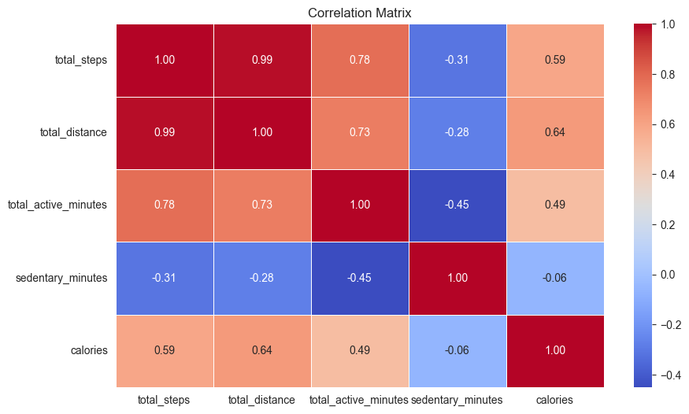

```python
correlation = ["total_steps", "total_distance", "total_active_minutes", "sedentary_minutes", "calories"]

fig, ax = plt.subplots(figsize=(10, 6))
ax = sb.heatmap(df_subset[correlation].corr(),
            annot = True,
            fmt = ".2f",
            linewidths=0.5,
           cmap="coolwarm")

ax.set_title('Correlation Matrix');
```

**Key Insights**

- On average, users walked 7,280 steps per day and burned 2,266 calories.
- The highest average step count was recorded on Saturdays (7,752 steps), while Sundays had the lowest average at 6,606 steps.
- A small subset of users demonstrated exceptional activity levels:
  - 2 users averaged over 12,000 steps per day.
  - 7 users walked more than 7 miles per day.
  - 3 users burned over 3,000 calories per day.
- The majority of users spent a significant portion of their day sedentary:
  - 992 minutes per day were spent inactive, compared to 218 minutes of active time on average.
- A strong correlation was observed between steps taken and distance traveled, which aligns with expectations.
- Factors influencing calorie expenditure:
  - Total active minutes and total steps had a positive correlation with calories burned.
  - Total distance traveled exhibited the strongest correlation with calorie expenditure.
- While sedentary time had a negative relationship with steps, distance, and active minutes, it showed almost no correlation with calories burned.

Maximizing total distance traveled and steps taken is the most effective way to burn calories, whereas the amount of sedentary time has little to no impact on calorie expenditure.

# **6. Share**

Our analysis is now complete, and we will develop visualizations to effectively present our findings. Well-designed visuals enhance accessibility and emphasize key insights.

To illustrate the relationship between activity levels and calories burned, we have created three scatterplots:

Notably, users with higher step counts and greater distances traveled appear in the upper right quadrant, reinforcing the key takeaway: increasing steps and distance is the most effective way to maximize calorie burn.

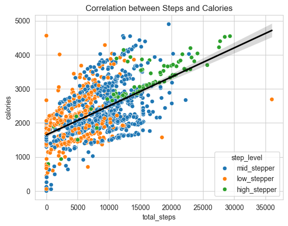

[figure not shown]

```python
ax = sb.scatterplot(data=df_subset, x='total_steps', y='calories', hue =df_subset['step_level'])
sb.regplot(x='total_steps', y='calories', data=df_subset, scatter=False, ax=ax, color='black')
plt.title('Correlation between Steps and Calories')
plt.show()

ax = sb.scatterplot(data=df_subset, x='total_steps', y='calories', hue =df_subset['distance_level'])
sb.regplot(x='total_steps', y='calories', data=df_subset, scatter=False, ax=ax, color='black')
plt.title('Correlation between Distance and Calories')
plt.show()
```

The correlation between sedentary time and calories burned is slightly negative, but close to zero, as shown in our final scatterplot.

While remaining inactive all day won’t contribute to calorie burn, the data suggests that sedentary time has no significant impact on overall caloric output. Many users in the lower left quadrant, who spent less time sedentary, still burned fewer calories than those in the upper right quadrant, who were inactive for over 1,200 minutes. This reinforces the idea that steps taken and distance traveled are the key drivers of calorie expenditure, while time spent sedentary has minimal influence.

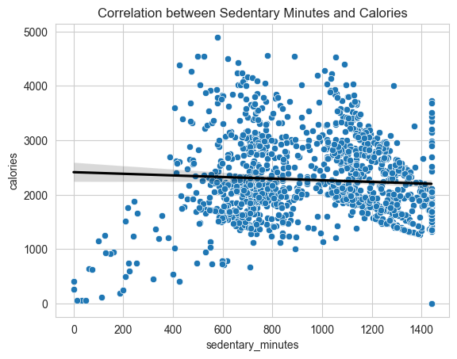

```python
ax = sb.scatterplot(data=df_subset, x='sedentary_minutes', y='calories')
sb.regplot(x='sedentary_minutes', y='calories', data=df_subset, scatter=False, ax=ax, color='black')
plt.title('Correlation between Sedentary Minutes and Calories')
plt.show()
```

Users' activity levels vary throughout the week, and visualizing these trends with a bar graph helps illustrate average daily step counts and time spent inactive.

While weekday activity remains relatively consistent, Mondays and Wednesdays see slightly higher step counts compared to Tuesdays. However, the weekends show the most noticeable contrast—Saturdays have the highest step counts, while Sundays see a significant drop in activity.

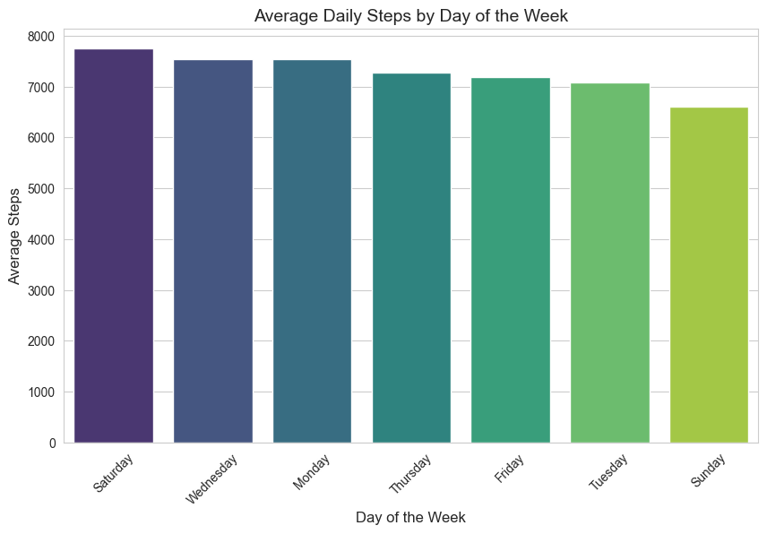

```python
# Set figure size and style
plt.figure(figsize=(10, 6))
sb.set_style("whitegrid")

# Convert avg_daily_steps to a DataFrame for compatibility
df_avg_steps = avg_daily_steps.reset_index()
df_avg_steps.columns = ['day_of_week', 'avg_steps']

# Plot the bar chart with hue set to 'day_of_week'
sb.barplot(data=df_avg_steps, x='day_of_week', y='avg_steps', hue='day_of_week', palette="viridis", legend=False)

# Customize labels and title
plt.xlabel("Day of the Week", fontsize=12)
plt.ylabel("Average Steps", fontsize=12)
plt.title("Average Daily Steps by Day of the Week", fontsize=14)

plt.xticks(rotation=45) # Rotate x-axis labels for better readability
# Show the plot
plt.show()
```

```python
avg_sedentary_minutes = df_subset.groupby('day_of_week')['sedentary_minutes'].mean().round(2).sort_values(ascending=False) # Calculating the average sedentary minutes for each day of the week and sorting in descending order.

# Convert avg_sedentary_minutes to a DataFrame for compatibility
df_avg_sedentary_minutes = avg_sedentary_minutes.reset_index()
df_avg_sedentary_minutes.columns = ['day_of_week', 'avg_sedentary_minutes']

df_avg_sedentary_minutes.head(7)
```

|  | day_of_week | avg_sedentary_minutes |
| --- | --- | --- |
| 0 | Monday | 1029.72 |
| 1 | Friday | 1020.27 |
| 2 | Sunday | 999.73 |
| 3 | Wednesday | 994.71 |
| 4 | Thursday | 984.90 |
| 5 | Saturday | 968.93 |
| 6 | Tuesday | 956.39 |

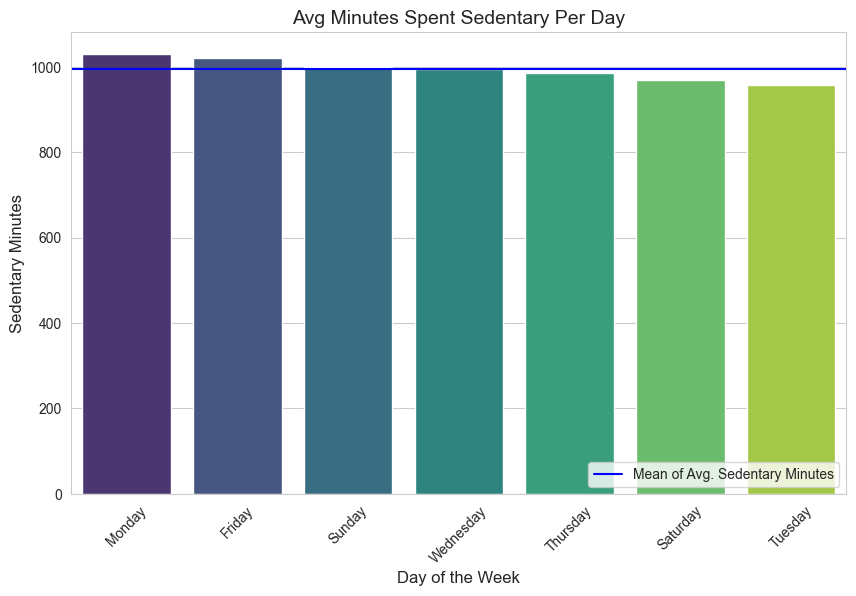

```python
# Set figure size and style
plt.figure(figsize=(10, 6))
sb.set_style("whitegrid")

# Plot the bar chart with hue set to 'day_of_week'
sb.barplot(data=df_avg_sedentary_minutes, x='day_of_week', y='avg_sedentary_minutes', hue='day_of_week', palette="viridis", legend=False)
plt.axhline(y=avg_sedentary_minutes.mean(), color='blue',label='Mean of Avg. Sedentary Minutes')

# Customize labels and title
plt.xlabel("Day of the Week", fontsize=12)
plt.ylabel("Sedentary Minutes", fontsize=12)
plt.title("Avg Minutes Spent Sedentary Per Day", fontsize=14)
plt.legend(loc = "lower right")
plt.xticks(rotation=45) # Rotate x-axis labels for better readability
# Show the plot
plt.show()
```

It is unsurprising that Saturdays, the day with the highest average step count, also had lower-than-average sedentary time.

However, a surprising insight is that Tuesdays had the lowest sedentary time, despite users taking fewer-than-average steps on that day. While there is a negative relationship between steps, distance, and sedentary time, the correlation is not strong. This further reinforces the finding that periods of inactivity do not significantly impact overall activity levels or calorie expenditure.

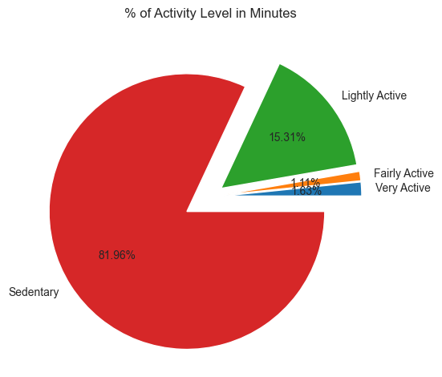

```python
very_active_mins = df_subset['very_active_minutes'].sum()
fairly_active_mins = df_subset['fairly_active_minutes'].sum()
lightly_active_mins = df_subset['lightly_active_minutes'].sum()
sedentary_mins = df_subset['sedentary_minutes'].sum()

slices = [very_active_mins, fairly_active_mins, lightly_active_mins, sedentary_mins]

labels = ['Very Active', 'Fairly Active', 'Lightly Active', 'Sedentary']
explode = [0.1,0.1,0.1,0.2]

plt.pie(slices, labels=labels, explode = explode, autopct = '%1.2f%%')
plt.title('% of Activity Level in Minutes')
plt.tight_layout()
```

The weak correlation between sedentary time and overall activity levels may be due to the fact that all users spent a significant portion of their day inactive.

This pie chart illustrates that 82% of recorded minutes were spent sedentary, while only 1.1% of minutes were classified as fairly active and 1.6% as very active. Despite the high percentage of inactivity, it did not hinder users from achieving their step goals or burning calories, suggesting that even brief periods of movement can contribute to overall activity levels.

# **7. Act**

### **Questions**

1. What are some trends in smart device usage?
- Users spend the majority of their time inactive, with only 18% of their logged minutes being active.
- Activity levels fluctuate throughout the week, with Saturdays being the most active and Sundays the least active on average.
- The most effective way to maximize calorie burn is by increasing steps taken and distance traveled.
2. How could these trends apply to Bellabeat customers?
- While the dataset comes from Fitbit users, the insights can be applied to Bellabeat customers to optimize their fitness experience.
- Encouraging users to set step goals or maintain a minimum daily distance can help improve calorie expenditure.
- Designing fitness plans that leverage high-activity Saturdays and accommodate lower-activity Sundays can align with natural user behavior, improving engagement and retention.
3. How could these trends help influence Bellabeat marketing strategy?
- Targeting active users who value step and distance tracking can enhance advertising effectiveness.
  - This can be achieved by placing ads on fitness-oriented websites such as SELF.com and WomensHealthMag.com or featuring Bellabeat products in popular gyms like Planet Fitness and LA Fitness.
  - A more impactful approach could include sponsoring fitness events, such as running groups or races, to actively engage with the fitness community.
- Given that users spend a significant amount of time inactive, marketing campaigns should also highlight Bellabeat’s features beyond activity tracking, such as sleep monitoring, heart rate tracking, and stylish designs, to align with a holistic health and wellness lifestyle.

### **Recommendation**

The key to boosting retention and attracting new users lies in customizing the Bellabeat experience to meet diverse user needs. By personalizing fitness plans and emphasizing them as a core feature, Bellabeat can appeal to users from all backgrounds.

By aligning Bellabeat’s marketing and product strategy with these insights, the company can strengthen user engagement, improve retention, and establish itself as a leader in the smart wellness device market.